# Assignment 3

Ishwar Choudhary & Shreya Banerjee

25/09/2019

```r
#q1
#install.packages("corrgram")
#install.packages("Metrics")
#install.packages('caret', repos='http://cran.us.r-project.org')
#install.packages("PCAmixdata")

#q4
#install.packages("glmnet")
#install.packages("psych")
#install.packages("Metrics")
```

```r
library("corrgram")
library("Metrics")
library("dplyr")
```

```r
library("corrplot")
library(PCAmixdata)
require(data.table)
set.seed(123)
library(glmnet)
library(dplyr)
library(psych)
library(Metrics)
```

# Question 1

a) Why is it necessary to do away with multicollinearity? Ans : When independent variables are correlated, it indicates that changes in one variable are associated with shifts in another variable.  
The stronger the correlation, the more difficult it is to change one variable without changing another. Hence it becomes difficult for the model to estimate the relationship between each independent variable and the dependent variable independently because the independent variables tend change and affect.  
b) Select only the quantitative variables and plot a correlogram to visualise the degree of correlation between pairs of variables. If you were to drop variables based on this plot, which one(s) would you drop and why? Go ahead and drop them from the train and test set. (Consider a threshold of 0.8)

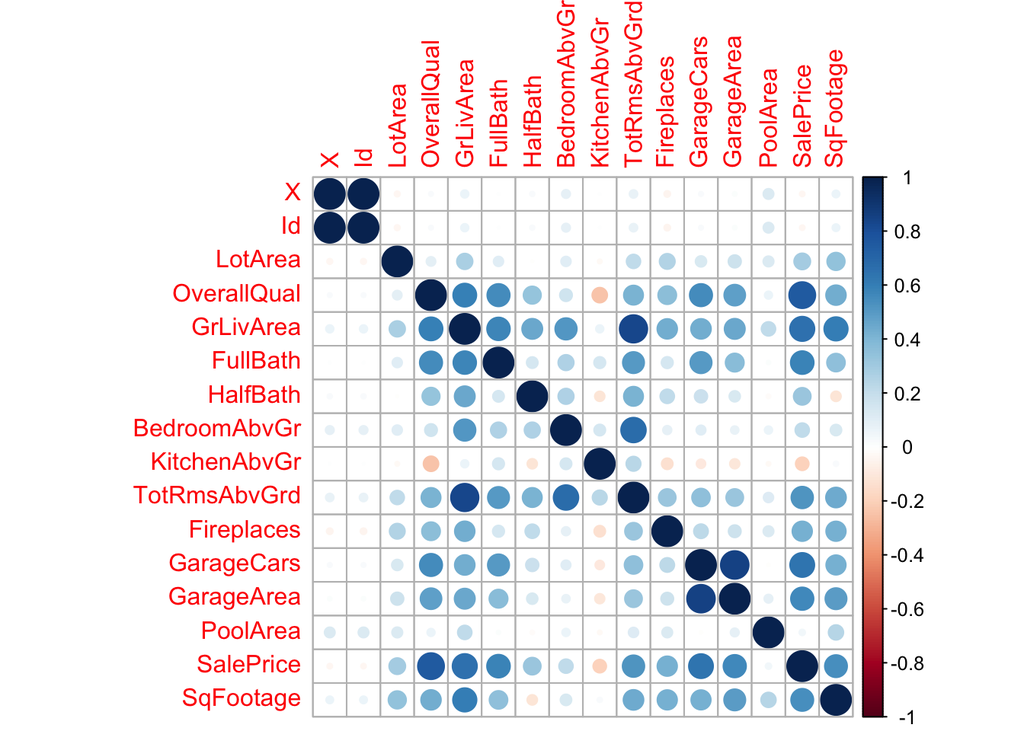

```r
#b) Correlogram visualization
#reference : https://www.statmethods.net/advgraphs/correlograms.html ; https://cran.r-project.org/web/packages/corrplot/vignettes/corrplot-intro.html
test_df  = read.csv("AmesHousingPrices/test.csv")
train_df  = read.csv("AmesHousingPrices/train.csv")

#taking only the quantitative features
test_quantitative = select_if(test_df, is.numeric) #this takes only the quantitative values from the df
train_quantitative = select_if(train_df, is.numeric)

M <- cor(test_quantitative)
corrplot(M, method = "circle")
```

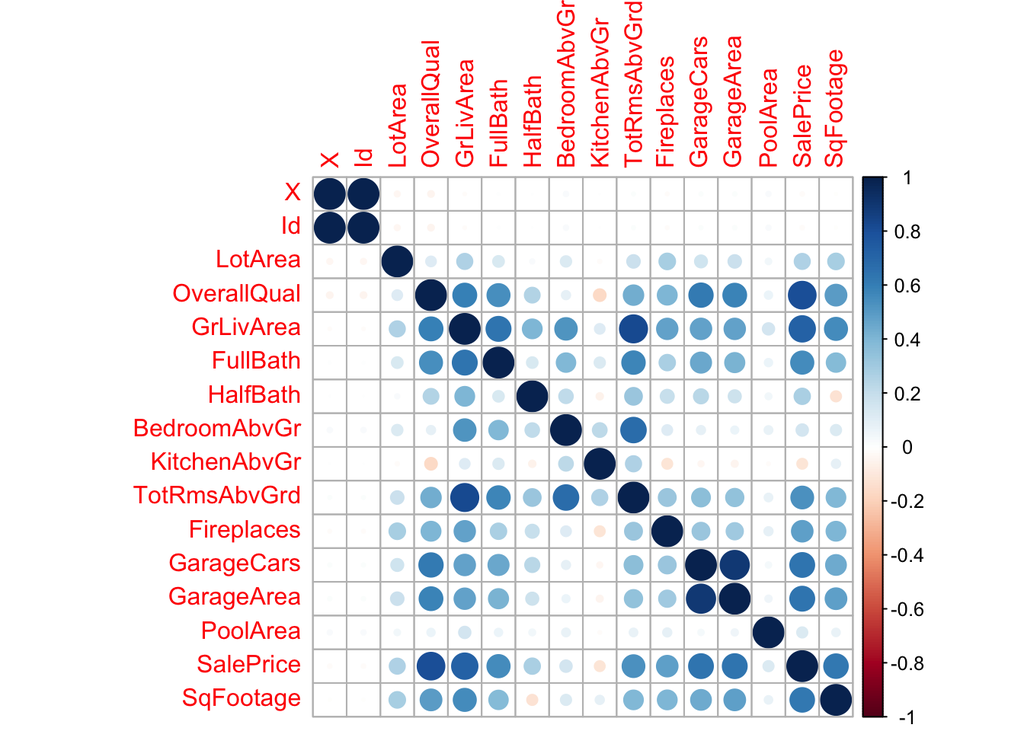

```r
N <- cor(train_quantitative)
corrplot(N, method = "circle")
```

```r
#correlation cutoff
#Reference : https://stackoverflow.com/questions/18275639/remove-highly-correlated-variables
#dropping of variables not working
#caret not working
```

3. Pearson’s correlation coefficient cannot be used on categorical variables. Provide a suitable visualisation for the relationship between a categorical variable and the target variable. Plot this graph for the variable “OverallQuality” and indicate its relationship with the target “SalePrice”. Why is this variable categorical?

```r
#Ref: https://stackoverflow.com/questions/5863097/selecting-only-numeric-columns-from-a-data-frame
#taking only the quantitative features
split1 <- splitmix(test_df)
split2 <- splitmix(train_df)
```

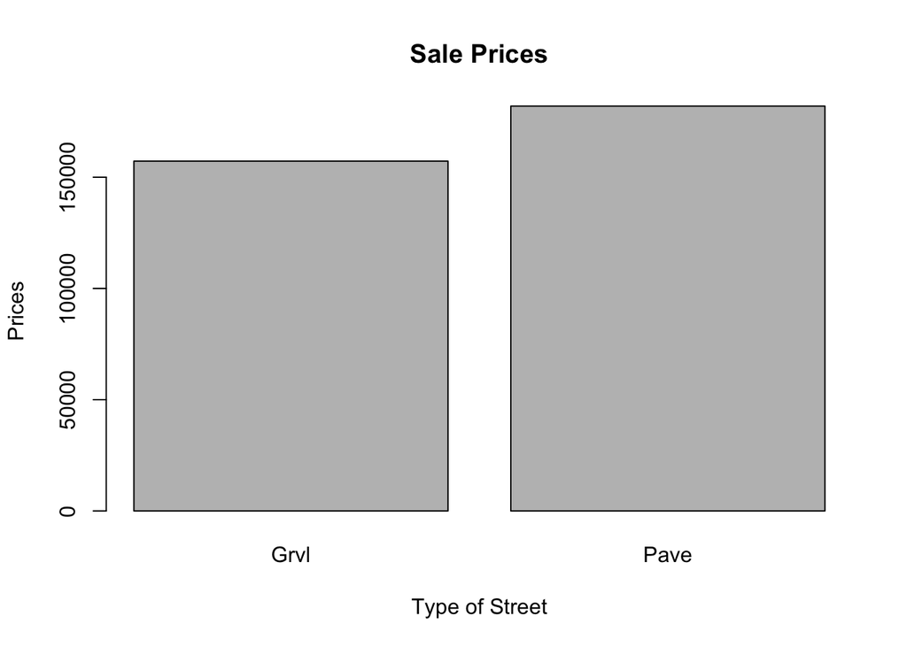

```r
test_qualitative =split1$X.quali #this takes only the quantitative values from the df
train_qualitative = split2$X.quali
#print(test_qualitative)
#print(train_qualitative)

train_qualitative$SalePrice = train_df$SalePrice

avg = aggregate(train_qualitative$SalePrice, by=list(Street=train_qualitative$Street), FUN=mean)
barplot(avg$x, main="Sale Prices",ylab="Prices",xlab="Type of Street",names.arg=avg$Street)
```

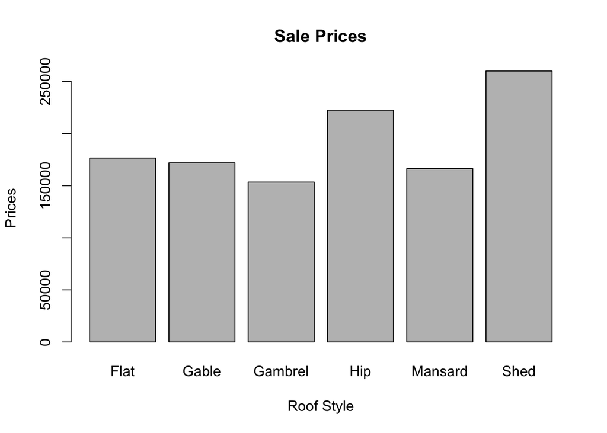

```r
avg = aggregate(train_qualitative$SalePrice, by=list(Street=train_qualitative$RoofStyle), FUN=mean)
barplot(avg$x, main="Sale Prices",ylab="Prices",xlab="Roof Style",names.arg=avg$Street)
```

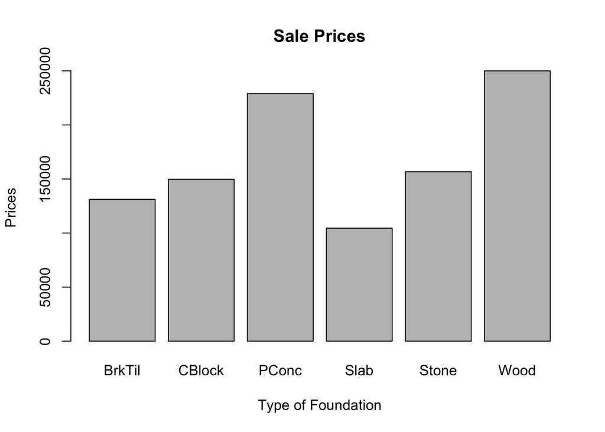

```r
avg = aggregate(train_qualitative$SalePrice, by=list(Street=train_qualitative$Foundation), FUN=mean)
barplot(avg$x, main="Sale Prices",ylab="Prices",xlab="Type of Foundation",names.arg=avg$Street)
```

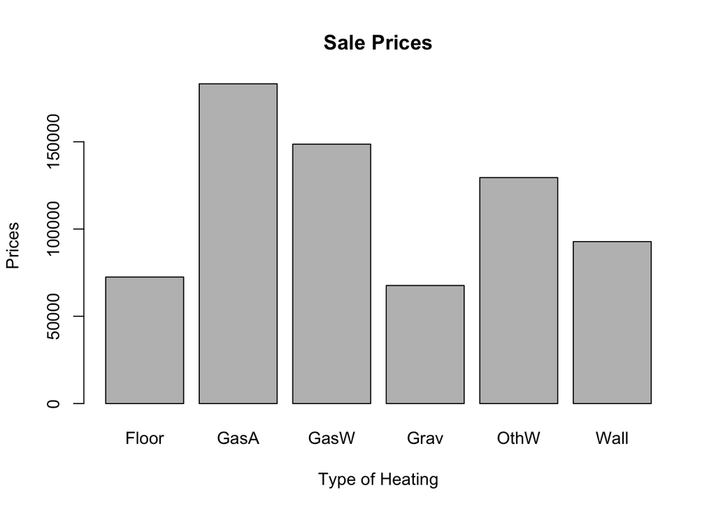

```r
avg = aggregate(train_qualitative$SalePrice, by=list(Street=train_qualitative$Heating), FUN=mean)
barplot(avg$x, main="Sale Prices",ylab="Prices",xlab="Type of Heating",names.arg=avg$Street)
```

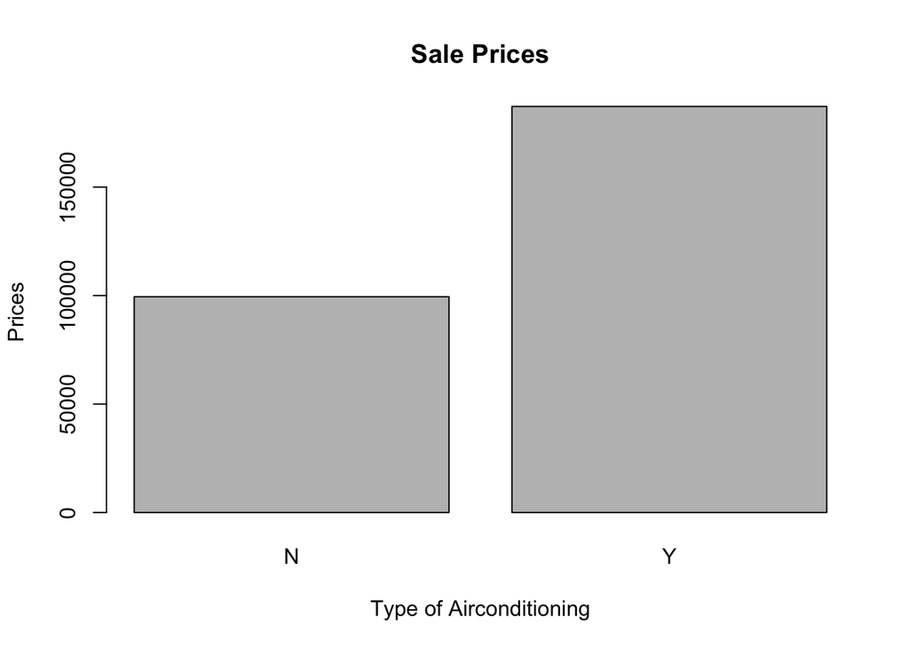

```r
avg = aggregate(train_qualitative$SalePrice, by=list(Street=train_qualitative$CentralAir), FUN=mean)
barplot(avg$x, main="Sale Prices",ylab="Prices",xlab="Type of Airconditioning",names.arg=avg$Street)
```

# Question 2

a)

```r
#LINEAR MODEL 1

linear_model1=lm(SalePrice ~ LotArea+OverallQual+factor(RoofStyle)+factor(Foundation)+factor(CentralAir)+GrLivArea+FullBath+HalfBath+BedroomAbvGr+factor(KitchenQual)+TotRmsAbvGrd+Fireplaces+GarageCars+GarageArea+PoolArea+SqFootage, data = train_df)
print(summary(linear_model1))
```

```
##
## Call:
## lm(formula = SalePrice ~ LotArea + OverallQual + factor(RoofStyle) +
##     factor(Foundation) + factor(CentralAir) + GrLivArea + FullBath +
##     HalfBath + BedroomAbvGr + factor(KitchenQual) + TotRmsAbvGrd +
##     Fireplaces + GarageCars + GarageArea + PoolArea + SqFootage,
##     data = train_df)
##
## Residuals:
##     Min      1Q  Median      3Q     Max
## -369602  -17456    -563   15968  256990
##
## Coefficients:
##                            Estimate Std. Error t value Pr(>|t|)
## (Intercept)              -3.600e+04  1.611e+04  -2.235  0.02560 *
## LotArea                   6.407e-01  1.290e-01   4.967 7.93e-07 ***
## OverallQual               1.706e+04  1.359e+03  12.553  < 2e-16 ***
## factor(RoofStyle)Gable    1.862e+04  1.122e+04   1.659  0.09734 .
## factor(RoofStyle)Gambrel  2.703e+04  1.588e+04   1.702  0.08903 .
## factor(RoofStyle)Hip      2.535e+04  1.136e+04   2.232  0.02584 *
## factor(RoofStyle)Mansard  8.113e+03  1.820e+04   0.446  0.65579
## factor(RoofStyle)Shed     3.379e+04  3.683e+04   0.918  0.35899
## factor(Foundation)CBlock  1.219e+04  4.022e+03   3.031  0.00250 **
## factor(Foundation)PConc   2.271e+04  4.413e+03   5.147 3.15e-07 ***
## factor(Foundation)Slab    7.909e+03  8.899e+03   0.889  0.37432
## factor(Foundation)Stone   2.026e+03  1.781e+04   0.114  0.90946
## factor(Foundation)Wood    2.512e+04  3.511e+04   0.715  0.47448
## factor(CentralAir)Y       1.144e+04  5.123e+03   2.232  0.02580 *
## GrLivArea                 4.625e+01  5.057e+00   9.145  < 2e-16 ***
## FullBath                  4.447e+02  2.914e+03   0.153  0.87875
## HalfBath                  4.823e+03  2.840e+03   1.699  0.08970 .
## BedroomAbvGr             -6.313e+03  1.925e+03  -3.280  0.00107 **
## factor(KitchenQual)Fa    -5.413e+04  8.905e+03  -6.079 1.68e-09 ***
## factor(KitchenQual)Gd    -4.980e+04  4.830e+03 -10.310  < 2e-16 ***
## factor(KitchenQual)TA    -5.970e+04  5.605e+03 -10.651  < 2e-16 ***
## TotRmsAbvGrd              4.232e+02  1.352e+03   0.313  0.75438
## Fireplaces                5.604e+03  2.027e+03   2.764  0.00581 **
## GarageCars                2.178e+03  3.301e+03   0.660  0.50951
## GarageArea                3.729e+01  1.138e+01   3.277  0.00108 **
## PoolArea                  6.315e+01  3.158e+01   2.000  0.04575 *
## SqFootage                 2.593e+01  4.356e+00   5.954 3.55e-09 ***
## ---
## Signif. codes:  0 '***' 0.001 '**' 0.01 '*' 0.05 '.' 0.1 ' ' 1
##
## Residual standard error: 34620 on 1068 degrees of freedom
## Multiple R-squared:  0.8246, Adjusted R-squared:  0.8203
## F-statistic: 193.1 on 26 and 1068 DF,  p-value: < 2.2e-16
```

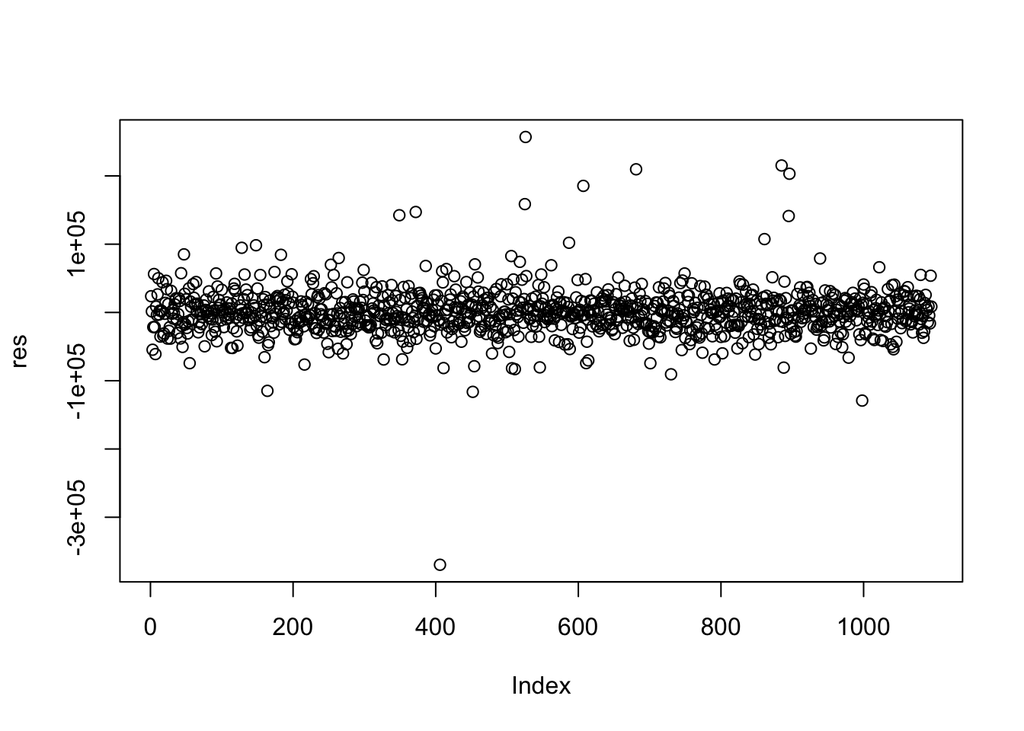

```r
res = resid(linear_model1)
plot(res)
```

b)An ideal residual plot should not have any trend or any outliers. Here, most of the point are concentrated around the zero but one point is far away(outlier).  
c)

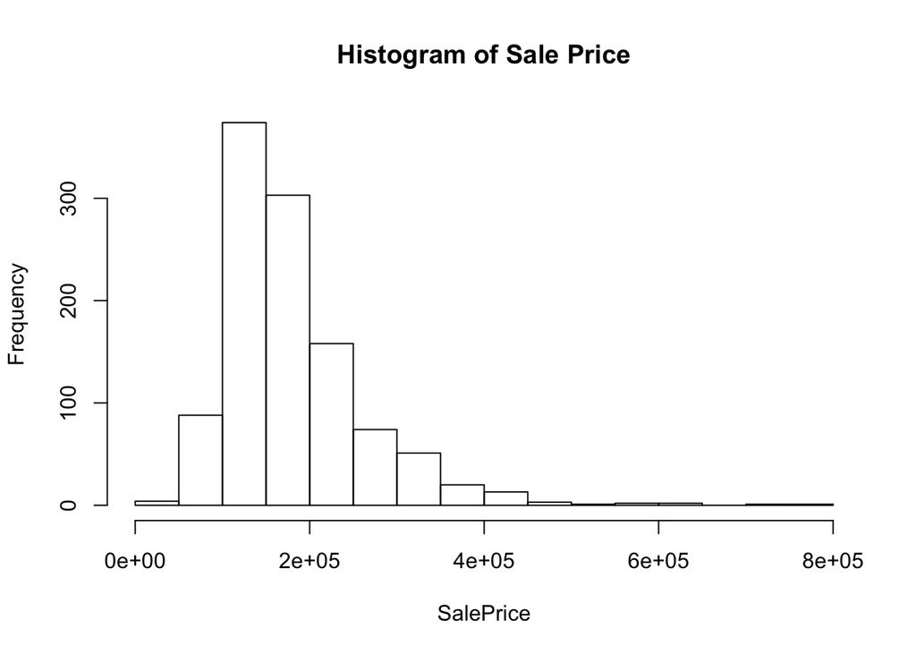

```r
hist(train_df$SalePrice,xlab="SalePrice",main="Histogram of Sale Price")
```

Since the histogram is right skewed, log transformation can be applied to make it normal.

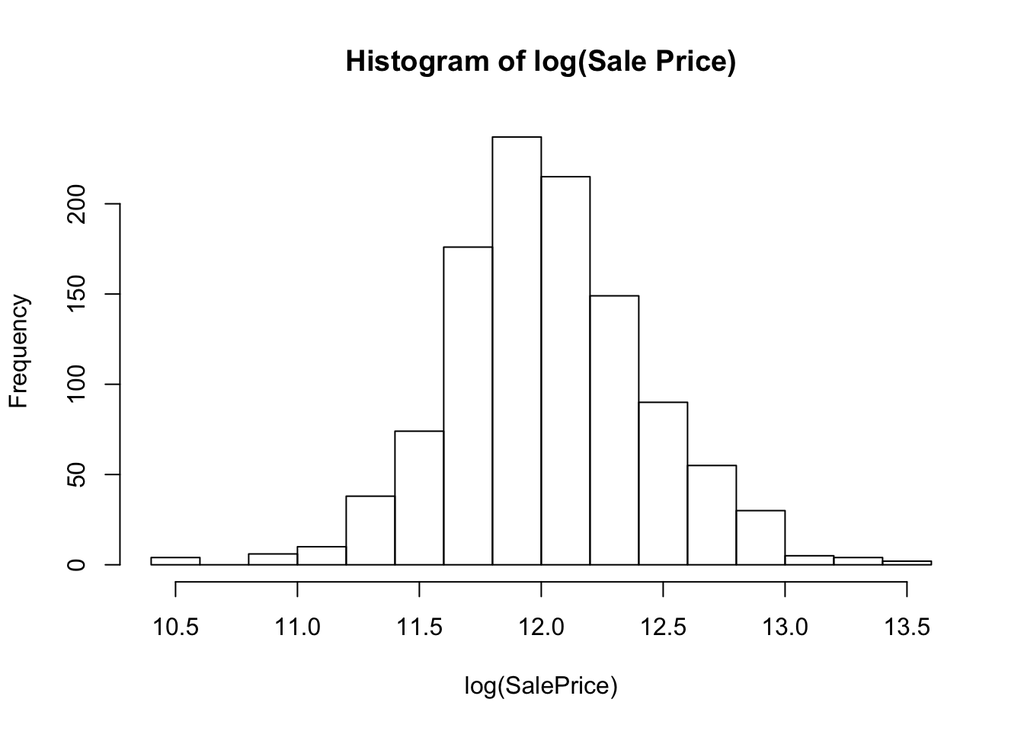

```r
hist(log1p(train_df$SalePrice),xlab="log(SalePrice)",main="Histogram of log(Sale Price)")
```

The histogram attains normal distribution after applying log transformation.

```r
#LINEAR MODEL 2
#The second model is built after applying log transformation on the dependent variable
linear_model2=lm(log1p(SalePrice) ~LotArea+OverallQual+factor(RoofStyle)+factor(Foundation)+factor(CentralAir)+GrLivArea+FullBath+HalfBath+BedroomAbvGr+factor(KitchenQual)+TotRmsAbvGrd+Fireplaces+GarageCars+GarageArea+PoolArea+SqFootage, data = train_df)
print(summary(linear_model2))
```

```
##
## Call:
## lm(formula = log1p(SalePrice) ~ LotArea + OverallQual + factor(RoofStyle) +
##     factor(Foundation) + factor(CentralAir) + GrLivArea + FullBath +
##     HalfBath + BedroomAbvGr + factor(KitchenQual) + TotRmsAbvGrd +
##     Fireplaces + GarageCars + GarageArea + PoolArea + SqFootage,
##     data = train_df)
##
## Residuals:
##      Min       1Q   Median       3Q      Max
## -1.46977 -0.07585  0.01036  0.09232  0.54250
##
## Coefficients:
##                            Estimate Std. Error t value Pr(>|t|)
## (Intercept)               1.061e+01  7.080e-02 149.832  < 2e-16 ***
## LotArea                   3.154e-06  5.670e-07   5.562 3.37e-08 ***
## OverallQual               9.380e-02  5.973e-03  15.703  < 2e-16 ***
## factor(RoofStyle)Gable    3.459e-02  4.933e-02   0.701 0.483309
## factor(RoofStyle)Gambrel  4.103e-02  6.982e-02   0.588 0.556932
## factor(RoofStyle)Hip      4.782e-02  4.994e-02   0.958 0.338469
## factor(RoofStyle)Mansard -4.499e-03  7.999e-02  -0.056 0.955161
## factor(RoofStyle)Shed     2.411e-01  1.619e-01   1.489 0.136765
## factor(Foundation)CBlock  8.470e-02  1.768e-02   4.790 1.90e-06 ***
## factor(Foundation)PConc   1.319e-01  1.940e-02   6.799 1.76e-11 ***
## factor(Foundation)Slab   -2.405e-02  3.912e-02  -0.615 0.538889
## factor(Foundation)Stone   9.074e-02  7.831e-02   1.159 0.246825
## factor(Foundation)Wood    2.201e-01  1.544e-01   1.426 0.154181
## factor(CentralAir)Y       1.786e-01  2.252e-02   7.932 5.41e-15 ***
## GrLivArea                 1.329e-04  2.223e-05   5.980 3.04e-09 ***
## FullBath                  3.317e-02  1.281e-02   2.589 0.009762 **
## HalfBath                  4.955e-02  1.248e-02   3.970 7.68e-05 ***
## BedroomAbvGr              3.479e-03  8.460e-03   0.411 0.680987
## factor(KitchenQual)Fa    -1.974e-01  3.915e-02  -5.044 5.36e-07 ***
## factor(KitchenQual)Gd    -8.994e-02  2.123e-02  -4.236 2.47e-05 ***
## factor(KitchenQual)TA    -1.645e-01  2.464e-02  -6.678 3.89e-11 ***
## TotRmsAbvGrd              3.515e-03  5.944e-03   0.591 0.554364
## Fireplaces                4.717e-02  8.913e-03   5.293 1.46e-07 ***
## GarageCars                2.780e-02  1.451e-02   1.916 0.055654 .
## GarageArea                1.777e-04  5.001e-05   3.553 0.000397 ***
## PoolArea                 -1.183e-04  1.388e-04  -0.852 0.394338
## SqFootage                 1.460e-04  1.915e-05   7.625 5.40e-14 ***
## ---
## Signif. codes:  0 '***' 0.001 '**' 0.01 '*' 0.05 '.' 0.1 ' ' 1
##
## Residual standard error: 0.1522 on 1068 degrees of freedom
## Multiple R-squared:  0.8637, Adjusted R-squared:  0.8603
## F-statistic: 260.2 on 26 and 1068 DF,  p-value: < 2.2e-16
```

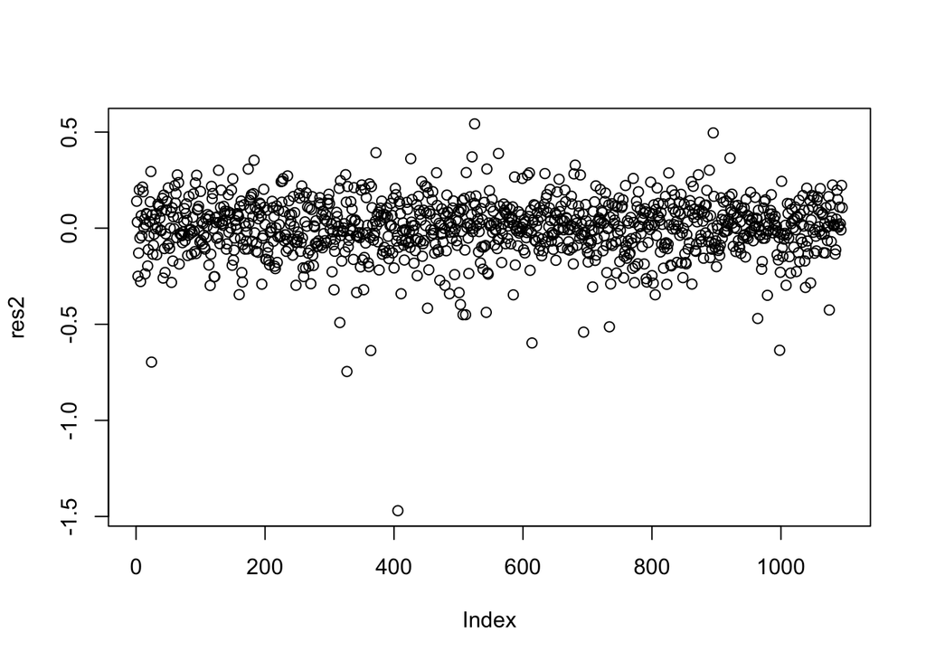

```r
res2 = resid(linear_model2)
plot(res2)
```

## Question 3

```r
predictions1 = predict.lm(linear_model1, test_df)
predictions2 = predict.lm(linear_model2, test_df)
mae1=mae(test_df$SalePrice,predictions1)
mae2=mae(test_df$SalePrice,exp(predictions2))
print(mae1)
```

```
## [1] 23458.19
```

```r
print(mae2)
```

```
## [1] 22272.71
```

# Question 4

1. When the model fits the training data but does not have a good predicting performance and generalization power, we use Regularisation. It is mostly used to avoid overfitting.

```r
data1=fread("ShenzhenHousingPrices/train.csv")
data_test=fread("ShenzhenHousingPrices/test.csv")


# Center y, X will be standardized in the modelling function
y <- data1 %>% select(SalePrice) %>% scale(center = TRUE, scale = FALSE) %>% as.matrix()
X1 <- data1 %>% select(-SalePrice)
X <-model.matrix(~.,data=X1)  #assigns dummy variables to the factor and leaves the numeric variables alone

# Perform 10-fold cross-validation to select lambda
lambdas_to_try <- 10^seq(-3, 5, length.out = 100)
# Setting alpha = 0 implements ridge regression
ridge_cv <- cv.glmnet(X, y, alpha = 0, lambda = lambdas_to_try,
                      standardize = TRUE, nfolds = 10)
#X is the matrix of input observations
#y is the vector of responses
#lambda is the vector of penalty terms

# Best cross-validated lambda
lambda_cv <- ridge_cv$lambda.min


y2 <- data_test %>% select(SalePrice) %>% scale(center = TRUE, scale = FALSE) %>% as.matrix()
X_ <- data_test %>% select(-SalePrice)
X2 <-model.matrix(~.,data=X_)

#fitting the model for test data
test_cv <- glmnet(X2, y2, alpha = 0, lambda = lambda_cv, standardize = TRUE)

y_hat <- predict(test_cv, X2)
ssr <- t(y2 - y_hat) %*% (y2 - y_hat)
rsq_ridge <- cor(y2, y_hat)^2

rmse_=rmse(y2,y_hat)

print(rsq_ridge)
```

```
##                  s0
## SalePrice 0.7379728
```

```r
print(rmse_)
```

```
## [1] 4.371031
```

```r
# Perform 10-fold cross-validation to select lambda
lambdas_to_try <- 10^seq(-3, 6, length.out = 100)

# Setting alpha = 1 implements lasso regression
lasso_cv <- cv.glmnet(X, y, alpha = 1, lambda = lambdas_to_try,
                      standardize = TRUE, nfolds = 10)

# Best cross-validated lambda
lambda_lasso <- lasso_cv$lambda.min

#fitting the model for test data
test_lasso_cv <- glmnet(X2, y2, alpha = 0, lambda = lambda_lasso, standardize = TRUE)

#predicted values of y for test data
y_hat_lasso <- predict(test_lasso_cv, X2)
ssr_lasso <- t(y2 - y_hat_lasso) %*% (y2 - y_hat_lasso)
rsq_lasso <- cor(y2, y_hat_lasso)^2
rmse_2=rmse(y2,y_hat_lasso)
print(rsq_lasso)
```

```
##                  s0
## SalePrice 0.7385191
```

```r
print(rmse_2)
```

```
## [1] 4.365544
```

4. Ridge regression adds “squared magnitude” of coefficient as penalty term to the loss function. Lasso Regression adds “absolute value of magnitude” of coefficient as penalty term to the loss function. “Ridge regression” uses all predictors in the final model whereas “Lasso regression” can be used for feature selection because coefficient values can be zero.